If the above code-block errors, install any missing libraries (`install.packages(c('LIBRARYNAME1', 'LIBRARYNAME2'))`)

## Introduction

This practical explores natural language processing (NLP) of unstructured clinical free-text from electronic medical records (EMR). You will work through an analysis going from raw text to an unsupervised topic model using the `MTSamples` medical transcription dataset.

The analyses you will do mirror some of those taken in the assigned readings and refer back to them for some questions:

- **Sun et al. (2024)** (Latent Dirichlet Allocation (LDA)-based topic modelling for clinical social work notes)
- **Chung et al. (2024)** (GPT-4 Turbo for classifying perioperative outcomes from pre-operative notes).

**Learning objectives:** by the end of this practical you should understand how to:

- apply regular expressions to search clinical free-text
- tokenise, normalise, stem, and lemmatize medical text
- compute TF-IDF to identify specialty-discriminating terms
- build a document-term matrix and fit an LDA topic model on clinical notes
- compare traditional NLP with LLM-based approaches

## Data Loading and Exploration

This lab is going to use the `MTSamples` medical transcription dataset. You can find the original source of this data [here](https://www.mtsamples.com/) (ignore any HTTP vs HTTPS related warnings).

```r
raw_data <- dataset_mtsamples()
glimpse(raw_data)
```

```
## Rows: 4,999
## Columns: 6
## $ note_id           <int> 1, 2, 3, 4, 5, 6, 7, 8, 9, 10, 11, 12, 13, 14, 15, 1…
## $ description       <chr> "A 23-year-old white female presents with complaint …
## $ medical_specialty <chr> "Allergy / Immunology", "Bariatrics", "Bariatrics", …
## $ sample_name       <chr> "Allergic Rhinitis", "Laparoscopic Gastric Bypass Co…
## $ transcription     <chr> "SUBJECTIVE:,  This 23-year-old white female present…
## $ keywords          <chr> "allergy / immunology, allergic rhinitis, allergies,…
```

I’ve not supplied a data dictionary with this dataset. This is a VERY common situation with real EMR data.

**Q1a (2 marks):** Based on the `glimpse()` output create a simple data dictionary (variable name with a 1-2 sentence explanation of the variable).

```
Q1a Answer:
| Variable          | Description                                                                                                                                |
| ----------------- | ------------------------------------------------------------------------------------------------------------------------------------------ |
| note_id           | A unique identifier assigned to each medical transcription record. It allows each note to be distinguished from all others in the dataset. |
| description       | A short summary describing the patient's condition, procedure, or reason for the medical encounter.                                        |
| medical_specialty | The medical specialty associated with the transcription, such as Surgery, Orthopedic, or Radiology.                                        |
| sample_name       | The title or name of the transcription sample, often describing the specific case or procedure.                                            |
| transcription     | The full free-text clinical note containing the detailed medical transcription. This is the primary text used for NLP analysis.            |
| keywords          | A set of keywords associated with the transcription that summarize important topics, diagnoses, or procedures mentioned in the note.       |
```

**Q1b (2 marks):** What sort of information are you missing about how this dataset was created that could be important to your analyses?

```
Q1b Answer:
Several important details about the creation of this dataset are not provided. First, the source of the records is unclear, including which hospitals, clinics, or geographic regions contributed the notes. Second, the time period during which the transcriptions were collected is not reported. Third, it is not specified whether the notes come from real patients, synthetic examples, or heavily edited records. Additional information about data collection methods, transcription quality, and specialty labeling procedures would also be useful. These factors could influence data quality, potential biases, and the generalizability of any conclusions drawn from the analysis.
```

**Q1c (2 marks):** How many distinct medical specialties are represented? What are the most common 5? Create a ggplot bar graph showing how many transcripts come from each specialty.

```
Q1c Answer:
The dataset contains 40 distinct medical specialties. The five most common specialties are Surgery, Consult - History and Physical, Cardiovascular/Pulmonary, Orthopedic, and Radiology. The bar graph shows that the distribution of transcripts is highly imbalanced across specialties. Surgery contains the largest number of records, while several specialties such as Allergy/Immunology and Hospice-Palliative Care contain relatively few notes. This imbalance may affect later analyses because specialties with more records contribute more information to statistical and NLP models.
```

#dplyr and ggplot code to count how many medical specialties are represented in the dataset and create a bar graph of them

To make patterns slightly easier to interpret for the sake of learning, we will simplify our dataset down to just transcripts from three specialties that have relatively distinct clinical vocabularies: neurological medicine, musculoskeletal/orthopaedic, and diagnostic imaging. In real analyses this is something you would have to infer from the data as part of your exploratory data analysis.

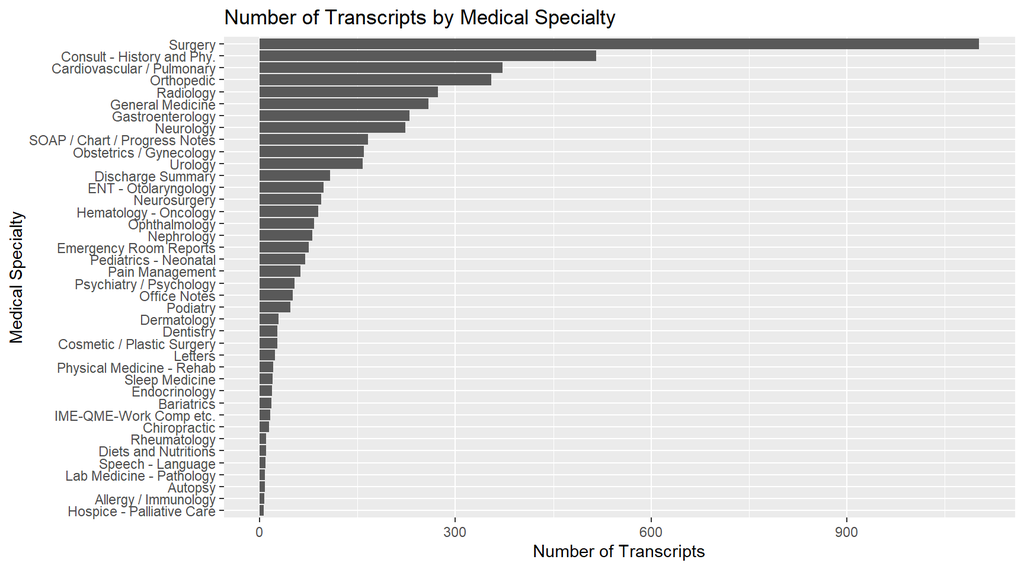

```r
specialty_counts <- raw_data |>
  count(medical_specialty, sort = TRUE)

ggplot(specialty_counts,
       aes(x = reorder(medical_specialty, n),
           y = n)) +
  geom_col() +
  coord_flip() +
  labs(
    title = "Number of Transcripts by Medical Specialty",
    x = "Medical Specialty",
    y = "Number of Transcripts")
```

```r
filtered_data <- raw_data |>
  filter(
    medical_specialty %in%
      c("Neurology", "Orthopedic", "Radiology"))
glimpse(filtered_data)
```

```
## Rows: 851
## Columns: 6
## $ note_id           <int> 13, 1486, 1487, 1489, 1490, 1491, 1492, 1493, 1494, …
## $ description       <chr> "Cerebral Angiogram - moyamoya disease.", "Ultrasoun…
## $ medical_specialty <chr> "Neurology", "Radiology", "Radiology", "Radiology", …
## $ sample_name       <chr> "Moyamoya Disease", "Ultrasound Scrotum", "X-RAY - N…
## $ transcription     <chr> "CC:, Confusion and slurred speech.,HX , (primarily …
## $ keywords          <chr> NA, "radiology, scrotal pain, epididymis, torsion, u…
```

## Regular Expressions

Now we are going to learn how to use the `stringr` library for regular expressions in R. Regular expressions (regex) enable flexible pattern-based searches over text. As discussed in the lecture, they are widely used in NLP (including as part of the framework around LLM systems) for finding measurements, medications, and semi- structured values embedded in free-text.

Key `stringr` functions:

| Function | Purpose |
| --- | --- |
| `str_detect(x, pat)` | Returns `TRUE`/`FALSE` per string |
| `str_count(x, pat)` | Number of non-overlapping matches |
| `str_extract(x, pat)` | First match |
| `str_extract_all(x, pat)` | All matches (returns a list) |

Key regex special characters (in R strings, backslashes must be doubled — e.g., `\d` is written `\\d`):

| Pattern | Meaning | Example match |
| --- | --- | --- |
| `\\d` | Any digit `[0-9]` | `"120"` in `"120 mg"` |
| `\\D` | Any non-digit | `"mg"` in `"120 mg"` |
| `\\w` | Word character `[a-zA-Z0-9_]` | `"bp"` in `"bp_value"` |
| `\\W` | Non-word character | `" "` in `"120 mg"` |
| `\\s` | Whitespace (space, tab, newline) | `" "` in `"120 mg"` |
| `\\S` | Non-whitespace | `"120"` in `"120 mg"` |
| `\\b` | Word boundary | matches position between `"120"` and `" "` |
| `.` | Any character except newline | `"1"`, `"a"`, `"/"` |
| `^` | Start of string | `"BP"` in `"BP: 120/80"` |
| `$` | End of string | `"mmHg"` at end of `"120/80 mmHg"` |
| `*` | 0 or more of preceding | `"\\d*"` matches `""` or `"123"` |
| `+` | 1 or more of preceding | `"\\d+"` matches `"1"` or `"123"` |
| `?` | 0 or 1 of preceding (optional) | `"mmHg?"` matches `"mmH"` or `"mmHg"` |
| `{n}` | Exactly *n* of preceding | `"\\d{3}"` matches `"120"` |
| `{n,m}` | Between *n* and *m* of preceding | `"\\d{2,3}"` matches `"12"` or `"120"` |
| `[abc]` | Any one character in set | `"[aeiou]"` matches any vowel |
| `[^abc]` | Any character *not* in set | `"[^0-9]"` matches non-digits |
| `(a\\|b)` | Either `a` or `b` | `"(mg\\|mcg)"` matches `"mg"` or `"mcg"` |
| `( )` | Capture group | `"(\\d+) mg"` captures the number |
| `[:alpha:]` | Any letter (POSIX class) | equivalent to `[a-zA-Z]` |
| `[:digit:]` | Any digit (POSIX class) | equivalent to `\\d` |
| `[:alnum:]` | Any letter or digit | equivalent to `[a-zA-Z0-9]` |
| `[:space:]` | Any whitespace (POSIX class) | equivalent to `\\s` |
| `[:punct:]` | Any punctuation character | `"."`, `","`, `"!"` |

### Finding blood pressure measurements

Blood pressure is typically recorded as systolic/diastolic (e.g., “120/80” or “130/85 mmHg”). We can therefore look for a pair of 2-3 digit numbers (`\\d{2,3}`) separated by a `/` (i.e., `\\d{2,3}/\\d{2,3}`) optionally followed by a pressure-related `mmHg` unit (with or without a preceding space `\\s*`). The special regex characters like `\\d` and `\\s` have that extra `\` so they are “escaped” and not treated as a literal character.

```r
bp_pattern <- "\\d{2,3}/\\d{2,3}(\\s*mmHg)?"
filtered_data |>
  mutate(has_bp = str_detect(transcription, bp_pattern)) |>
  count(medical_specialty, has_bp) |>
  pivot_wider(
    names_from = has_bp,
    values_from = n,
    names_prefix = "bp_"
  ) |>
  mutate(
    pct_with_bp = percent(
      bp_TRUE / (bp_TRUE + bp_FALSE),
      accuracy = 0.1))
```

```
## # A tibble: 3 × 4
##   medical_specialty bp_FALSE bp_TRUE pct_with_bp
##   <chr>                <int>   <int> <chr>
## 1 Neurology               92     131 58.7%
## 2 Orthopedic             269      86 24.2%
## 3 Radiology              179      94 34.4%
```

### Counting medication dosages

Now let’s look for medication doses. We can make a regex that finds one of the standard dosage units (e.g., `mg` `mcg`, `ml`, `mL` `unit`) preceded by some sort of number (`\\d+`) with or without a decimal point (`\\.?\\d*`).

```r
dose_pattern <- "\\d+\\.?\\d*\\s*(mg|mcg|ml|mL|units?)"

filtered_data |>
    mutate(n_doses = str_count(transcription, dose_pattern)) |>
    filter(n_doses > 0) |>
    group_by(medical_specialty) |>
    summarise(mean_doses   = round(mean(n_doses), 1),
              median_doses = median(n_doses))
```

```
## # A tibble: 3 × 3
##   medical_specialty mean_doses median_doses
##   <chr>                  <dbl>        <dbl>
## 1 Neurology                3.9            3
## 2 Orthopedic               2.1            1
## 3 Radiology                2.2            1
```

**Q2 (3 marks):** Write a regular expression to find temperature measurements in clinical text (e.g., “98.6 F”, “37.2°C”, “temperature of 38.1”, “afebrile”). Report how many notes in each specialty contain at least one temperature mention.

Regex builders like [this website](https://spannbaueradam.shinyapps.io/r_regex_tester/) can make it a lot quicker to iterate and improve your regular expressions!

```r
temp_pattern <- "(\\d{2,3}\\.?\\d*\\s*(F|C|°F|°C))|(temperature\\s*of\\s*\\d{2,3}\\.?\\d*)|afebrile"

filtered_data |>
  mutate(
    has_temp = str_detect(
      transcription,
      regex(temp_pattern, ignore_case = TRUE)
    )
  ) |>
  count(medical_specialty, has_temp) |>
  pivot_wider(
    names_from = has_temp,
    values_from = n,
    names_prefix = "temp_")
```

```
## # A tibble: 3 × 3
##   medical_specialty temp_FALSE temp_TRUE
##   <chr>                  <int>     <int>
## 1 Neurology                134        89
## 2 Orthopedic               256        99
## 3 Radiology                192        81
```

Q2 Answer: The regular expression used to identify temperature-related mentions was:

`(\\d{2,3}\\.?\\d*\\s*(F|C|°F|°C))|(temperature\\s*of\\s*\\d{2,3}\\.?\\d*)|afebrile`

## This pattern detects temperature measurements recorded with units such as “98.6 F” and “37.2°C”, textual descriptions such as “temperature of 38.1”, and the clinical term “afebrile”. The results showed that 89 Neurology notes, 99 Orthopedic notes, and 81 Radiology notes contained at least one temperature-related mention. These findings demonstrate how regular expressions can be used to extract clinically relevant information from unstructured medical text.

## Text Normalisation

A key stage in traditional text analysis is to normalise raw text — reducing variability due to capitalisation, punctuation, and common function words — before any modelling or analysis.

### Tokenisation and stop word removal

`tidytext::unnest_tokens()` splits text into individual tokens and lowercases everything. We then strip residual punctuation, drop very short tokens, and remove stop words (common words like “the”, “of”, “and” that carry little domain information):

```r
tokenised_data <- filtered_data |>
  unnest_tokens(word, transcription, to_lower = TRUE) |>
  mutate(word = str_replace_all(word, "[^[:alpha:]]", "")) |>
  filter(str_length(word) > 1) |>
  anti_join(stop_words, by = "word")

glimpse(tokenised_data)
```

```
## Rows: 197,966
## Columns: 6
## $ note_id           <int> 13, 13, 13, 13, 13, 13, 13, 13, 13, 13, 13, 13, 13, …
## $ description       <chr> "Cerebral Angiogram - moyamoya disease.", "Cerebral …
## $ medical_specialty <chr> "Neurology", "Neurology", "Neurology", "Neurology", …
## $ sample_name       <chr> "Moyamoya Disease", "Moyamoya Disease", "Moyamoya Di…
## $ keywords          <chr> NA, NA, NA, NA, NA, NA, NA, NA, NA, NA, NA, NA, NA, …
## $ word              <chr> "cc", "confusion", "slurred", "speech", "hx", "prima…
```

**Q3 (2 marks):** How many stop words are in the `stop_words` list, how many different `lexicon` are included, and which `lexicon` contains the most stop words? Answer these questions using code below and create a bargraph of the number of unique stop words per lexicon.

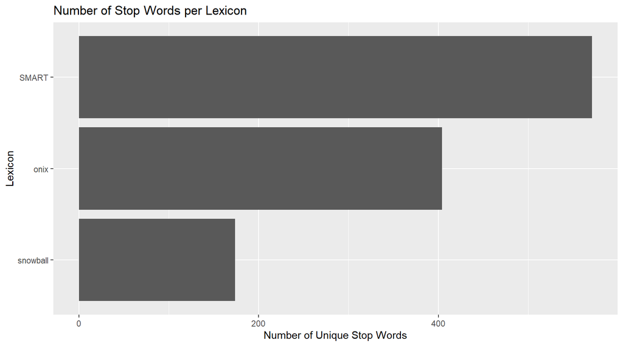

```
Q3 Answer:
The stop_words dataset contains 1,149 stop words in total. There are 3 different lexicons included in the dataset: SMART, onix, and snowball. The SMART lexicon contains the largest number of stop words with 571 words, followed by onix with 404 words and snowball with 174 words.
The bar graph shows that SMART contains the highest number of unique stop words, while snowball contains the fewest. This demonstrates that different stop-word lexicons vary in size and coverage.
```

```r
stop_words |>
  count(lexicon, name = "n_stopwords") |>
  ggplot(aes(x = reorder(lexicon, n_stopwords),
             y = n_stopwords)) +
  geom_col() +
  coord_flip() +
  labs(
    title = "Number of Stop Words per Lexicon",
    x = "Lexicon",
    y = "Number of Unique Stop Words")
```

**Q4 (2 marks):** How many *unique* unigrams (distinct words) are there in total across all the cleaned and tokenised transcriptions for each specialty? Which specialty has the largest vocabulary and which the smallest? Complete the code below, then provide a 1-2 sentence interpretation of the output.

```r
tokenised_data |>
  group_by(medical_specialty) |>
  summarise(unique_words = n_distinct(word))
```

```
## # A tibble: 3 × 2
##   medical_specialty unique_words
##   <chr>                    <int>
## 1 Neurology                 7515
## 2 Orthopedic                7691
## 3 Radiology                 5969
```

```r
tokenised_data |>
  group_by(medical_specialty, note_id) |>
  summarise(unique_words = n_distinct(word), .groups = "drop") |>
  group_by(medical_specialty) |>
  summarise(mean_unique_words = mean(unique_words))
```

```
## # A tibble: 3 × 2
##   medical_specialty mean_unique_words
##   <chr>                         <dbl>
## 1 Neurology                      175.
## 2 Orthopedic                     168.
## 3 Radiology                      105.
```

[output not shown]

### Bigrams

We can also combined consecutive words into two-word phrases (bigrams) which better capture medical compound terms that unigrams split apart (e.g., “blood pressure”, “right knee”, “general anaesthesia”):

```r
bigrams <- filtered_data |>
  unnest_tokens(bigram, transcription, token = "ngrams",
                n = 2, to_lower = TRUE) |>
  filter(!is.na(bigram)) |>
  mutate(word1 = word(bigram, 1),
         word2 = word(bigram, 2)) |>
  filter(!word1 %in% stop_words$word,
         !word2 %in% stop_words$word,
         !str_detect(word1, "\\d"),
         !str_detect(word2, "\\d")) |>
  select(-word1, -word2)

bigrams |>
  count(medical_specialty, bigram, sort = TRUE) |>
  slice_max(n, n = 6, by = medical_specialty, with_ties = FALSE) |>
  arrange(medical_specialty)
```

```
##    medical_specialty                  bigram   n
## 1          Neurology       lower extremities  74
## 2          Neurology         medical history  68
## 3          Neurology            past medical  56
## 4          Neurology    physical examination  49
## 5          Neurology         upper extremity  49
## 6          Neurology         lower extremity  48
## 7         Orthopedic  preoperative diagnosis 141
## 8         Orthopedic         lower extremity 139
## 9         Orthopedic postoperative diagnosis 124
## 10        Orthopedic              blood loss 110
## 11        Orthopedic           carpal tunnel 110
## 12        Orthopedic         upper extremity 106
## 13         Radiology          carotid artery  59
## 14         Radiology              heart rate  52
## 15         Radiology        left ventricular  50
## 16         Radiology         coronary artery  43
## 17         Radiology           central canal  42
## 18         Radiology       ejection fraction  42
```

**Q5 (1 mark):** What is the most common bigram in each specialty?

Q5 Answer: The most common bigram in Neurology was “lower extremities” with 74 occurrences. The most common bigram in Orthopedic was “preoperative diagnosis” with 141 occurrences. The most common bigram in Radiology was “carotid artery” with 59 occurrences. These bigrams reflect the clinical focus of each specialty. Neurology notes frequently discuss examination findings involving the extremities, Orthopedic notes commonly reference surgical diagnoses and procedures, and Radiology reports often focus on anatomical structures and imaging findings such as the carotid artery.

| Specialty | Most Common Bigram | Frequency |
| --- | --- | --- |
| Neurology | lower extremities | 74 |
| Orthopedic | preoperative diagnosis | 141 |
| Radiology | carotid artery | 59 |

```r
bigrams <- filtered_data |>
  unnest_tokens(bigram, transcription, token = "ngrams",
                n = 2, to_lower = TRUE) |>
  filter(!is.na(bigram)) |>
  mutate(word1 = word(bigram, 1),
         word2 = word(bigram, 2)) |>
  filter(!word1 %in% stop_words$word,
         !word2 %in% stop_words$word,
         !str_detect(word1, "\\d"),
         !str_detect(word2, "\\d")) |>
  select(-word1, -word2)

bigrams |>
  count(medical_specialty, bigram, sort = TRUE) |>
  slice_max(n, n = 6, by = medical_specialty, with_ties = FALSE) |>
  arrange(medical_specialty)
```

```
##    medical_specialty                  bigram   n
## 1          Neurology       lower extremities  74
## 2          Neurology         medical history  68
## 3          Neurology            past medical  56
## 4          Neurology    physical examination  49
## 5          Neurology         upper extremity  49
## 6          Neurology         lower extremity  48
## 7         Orthopedic  preoperative diagnosis 141
## 8         Orthopedic         lower extremity 139
## 9         Orthopedic postoperative diagnosis 124
## 10        Orthopedic              blood loss 110
## 11        Orthopedic           carpal tunnel 110
## 12        Orthopedic         upper extremity 106
## 13         Radiology          carotid artery  59
## 14         Radiology              heart rate  52
## 15         Radiology        left ventricular  50
## 16         Radiology         coronary artery  43
## 17         Radiology           central canal  42
## 18         Radiology       ejection fraction  42
```

### Sentence segmentation

Another common text processing step is to split our text into distinct sentences. Again our old friend `unnest_tokens` can do a lot of the heavy lifting!

```r
sentences_data <- filtered_data |>
  unnest_tokens(sentence, transcription,
                token = "sentences", to_lower = FALSE)

sentences_data |>
  group_by(medical_specialty) |>
  summarise(total_sentences = n(),
            n_notes = n_distinct(note_id),
            mean_per_note = round(total_sentences / n_notes, 1))
```

```
## # A tibble: 3 × 4
##   medical_specialty total_sentences n_notes mean_per_note
##   <chr>                       <int>   <int>         <dbl>
## 1 Neurology                    6758     223          30.3
## 2 Orthopedic                  11738     355          33.1
## 3 Radiology                    4643     273          17
```

**Q6 (1 mark):** How many *unique* sentences are there in each specialty? Uncomment and complete the code below (replace each `___` with the correct column name):

```r
sentences_data |>
  group_by(medical_specialty) |>
  summarise(unique_sentences = n_distinct(sentence))
```

```
## # A tibble: 3 × 2
##   medical_specialty unique_sentences
##   <chr>                        <int>
## 1 Neurology                     6647
## 2 Orthopedic                   11175
## 3 Radiology                     4567
```

```
Q6 Answer:
Orthopedic had the largest number of unique sentences (11,175), followed by Neurology (6,647). Radiology had the smallest number of unique sentences (4,567).
This suggests that Orthopedic notes contain greater variation in sentence structure and clinical descriptions, while Radiology reports tend to use more standardized and repetitive language. The lower number of unique sentences in Radiology is consistent with the structured nature of imaging reports.
```

## Stemming and Lemmatization

However, given how noisy language is and the many variants of the same word (alternative suffixes) like pluralisation or possessive apostrophes. We also often want to “normalise” words to a common base form. There are two main approaches to this:

- **Stemming**-crude suffix stripping, fast but imprecise: “operating” to “operat” (`SnowballC::wordStem`)
- **Lemmatization**-linguistically informed root form: “operating” to “operate” (`textstem::lemmatize_words`)

  We can apply these normalisations using the associated library functions.

```r
word_sample <- tokenised_data |>
  distinct(word) |>
  mutate(stem  = SnowballC::wordStem(word, language = "english"),
         lemma = textstem::lemmatize_words(word))

word_sample |>
  filter(word != stem | word != lemma) |>
  select(word, stem, lemma) |>
  slice_head(n = 15)
```

```
##            word      stem        lemma
## 1     confusion    confus    confusion
## 2       slurred      slur         slur
## 3     primarily primarili    primarily
## 4      obtained    obtain       obtain
## 5   experienced experienc   experience
## 6       illness       ill      illness
## 7         weeks      week         week
## 8  presentation   present presentation
## 9         found     found         find
## 10       passed      pass         pass
## 11       awoken    awoken        awake
## 12     appeared    appear       appear
## 13     confused    confus      confuse
## 14    lethargic   letharg    lethargic
## 15   apparently     appar   apparently
```

**Q7 (1 mark):** Does lemmatising or stemming result in fewer unique words?

```r
tokenised_data |>
  summarise(
    original_words = n_distinct(word),
    stemmed_words = n_distinct(SnowballC::wordStem(word, language = "english")),
    lemmatised_words = n_distinct(textstem::lemmatize_words(word))
  )
```

```
##   original_words stemmed_words lemmatised_words
## 1          11647          8239             9358
```

[output not shown]

**Q8 (2 marks):** In 2-3 sentences explain why a general-purpose English lemmatizer is likely to perform poorly on medical transcription text. Give at least two examples of medical terms that would likely be handled incorrectly and describe what goes wrong.

```
Q8 Answer:
A general-purpose English lemmatizer is likely to perform poorly on medical transcription text because it is designed for everyday English vocabulary and may not recognize specialized medical terminology, abbreviations, or clinical jargon. As a result, medical words may be incorrectly transformed or left unchanged.
For example, the abbreviation "hx" (history) may not be recognized as a medical abbreviation and therefore will not be correctly lemmatized. Similarly, terms such as "neuropathies" or "cardiomyopathies" may be reduced incorrectly because the lemmatizer does not fully understand their medical roots and meanings. These errors can reduce the accuracy of text analysis by failing to group related medical concepts correctly.
```

### Applying lemmatisation to the full dataset

Now let’s lemmatise the full dataset:

```r
unique_lemmas <- tokenised_data |>
  distinct(word) |>
  mutate(lemma = textstem::lemmatize_words(word))

lemmatised_data <- tokenised_data |>
  left_join(unique_lemmas, by = "word")
```

We can now look more easily at the most frequent (lemmatised) words per specialty

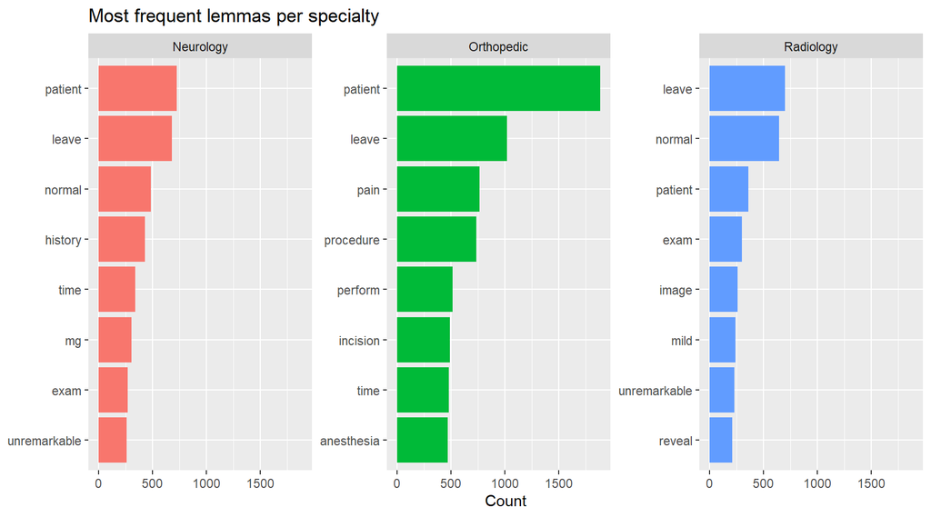

```r
lemmatised_data |>
  count(medical_specialty, lemma, sort = TRUE) |>
  slice_max(n, n = 8, by = medical_specialty, with_ties = FALSE) |>
  ggplot(aes(n, reorder_within(lemma, n, medical_specialty),
             fill = medical_specialty)) +
  geom_col(show.legend = FALSE) +
  facet_wrap(~medical_specialty, scales = "free_y") +
  scale_y_reordered() +
  labs(title = "Most frequent lemmas per specialty",
       x = "Count", y = NULL)
```

## TF-IDF: Finding Discriminating Terms

Unfortunately, as you can see above, raw counts are dominated by generic medical words (“patient”, “history”, “left”). TF-IDF (term frequency–inverse document frequency) down-weights terms common across all documents and up-weights terms characteristic of a specific category. Sun et al. (2024) used word-frequency analysis as a first step before LDA to explore the vocabulary of their social work notes.

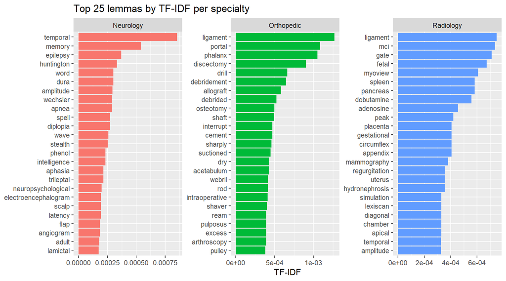

```r
specialty_tfidf <- lemmatised_data |>
  count(medical_specialty, lemma) |>
  bind_tf_idf(lemma, medical_specialty, n)

specialty_tfidf |>
  group_by(medical_specialty) |>
  slice_max(tf_idf, n = 25, with_ties = FALSE) |>
  ggplot(aes(tf_idf,
             reorder_within(lemma, tf_idf, medical_specialty),
             fill = medical_specialty)) +
  geom_col(show.legend = FALSE) +
  facet_wrap(~medical_specialty, scales = "free") +
  scale_y_reordered() +
  labs(title = "Top 25 lemmas by TF-IDF per specialty",
       x = "TF-IDF", y = NULL)
```

**Q9 (2 marks):** Do the top TF-IDF terms make clinical sense for each specialty? Identify one term that surprises you from any specialty. Complete the code below by replacing `"your_term_here"` with that term to pull an example transcription containing it, then briefly explain its clinical context.

```r
filtered_data |>
  filter(str_detect(transcription, "osteotomy")) |>
  slice(1) |>
  pull(transcription) |>
  str_trunc(600)
```

```
## [1] "PREOPERATIVE DIAGNOSES:,1.  Hallux abductovalgus deformity, right foot.,2.  Tailor bunion deformity, right foot.,POSTOPERATIVE DIAGNOSES:,1.  Hallux abductovalgus deformity, right foot.,2.  Tailor bunion deformity, right foot.,PROCEDURES PERFORMED:  ,Tailor bunionectomy, right foot, Weil-typ…
```

[output not shown]

### Comparing lemma proportions across specialties

Now let’s compare across specialties. This plot shows each lemma’s proportion in Orthopedic notes (y-axis) against its proportion in Radiology or Neurology (x-axis, one facet each). Terms near the dashed diagonal are used similarly in both specialties; terms far from it are specialty-specific.

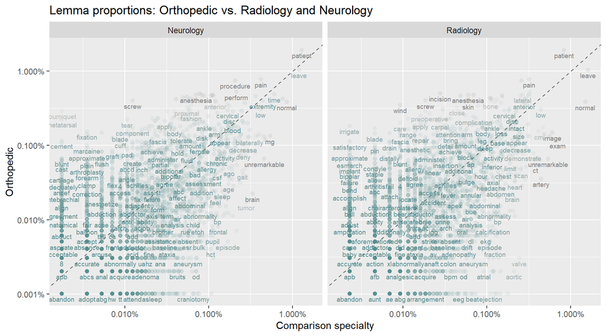

```r
specialty_props <- lemmatised_data |>
  count(medical_specialty, lemma) |>
  group_by(medical_specialty) |>
  mutate(proportion = n / sum(n)) |>
  ungroup() |>
  pivot_wider(id_cols     = lemma,
              names_from  = medical_specialty,
              values_from = proportion,
              values_fill = 0) |>
  pivot_longer(c(Radiology, Neurology),
               names_to  = "comparison_specialty",
               values_to = "proportion")

ggplot(specialty_props |> filter(proportion > 0, Orthopedic > 0),
       aes(x = proportion, y = Orthopedic,
           colour = abs(Orthopedic - proportion))) +
  geom_abline(colour = "grey40", linetype = 2) +
  geom_jitter(alpha = 0.1, size = 1.8, width = 0.0003, height = 0.0003) +
  geom_text(aes(label = lemma), check_overlap = TRUE,
            vjust = 1.5, size = 2.5) +
  scale_x_log10(labels = percent_format(accuracy = 0.001)) +
  scale_y_log10(labels = percent_format(accuracy = 0.001)) +
  scale_colour_gradient(limits = c(0, 0.003),
                        low = "darkslategray4", high = "gray75") +
  facet_wrap(~comparison_specialty) +
  theme(legend.position = "none") +
  labs(y = "Orthopedic", x = "Comparison specialty",
       title = "Lemma proportions: Orthopedic vs. Radiology and Neurology")
```

**Q10 (2 marks):** What does this plot tell you about the lexical similarity between Orthopedic and Neurology compared with Orthopedic and Radiology? Is this what you would expect given the clinical roles of each specialty? Justify your answer in 2-4 sentences.

```
Q10 answer:
The plot shows that Orthopedic notes have many specialty-specific terms that differ from both Neurology and Radiology, as evidenced by the numerous points located far from the diagonal line. Terms close to the diagonal are used at similar frequencies across specialties, while those farther away are more characteristic of a particular specialty.
This is consistent with clinical expectations. Orthopedic medicine focuses on musculoskeletal injuries and surgical procedures, whereas Neurology focuses on disorders of the nervous system and Radiology focuses on diagnostic imaging. Therefore, each specialty develops its own distinct vocabulary, resulting in relatively low lexical similarity between them.
```

## Topic Modelling with Latent Dirichlet Allocation

Latent Dirichlet Allocation (LDA) is an unsupervised probabilistic model that treats each document as a mixture of topics and each topic as a probability distribution over words. Unlike supervised classifiers, LDA discovers thematic structure from the text alone-no specialty labels are used during training. This mirrors the approach of Sun et al. (2024), who applied LDA to clinical social work notes to uncover latent SDoH themes without predefined categories.

Two key outputs of a fitted LDA model:

| Output | Symbol | Interpretation |
| --- | --- | --- |
| Word–topic matrix | β (beta) | Probability that word *w* is generated by topic *k* |
| Document–topic matrix | γ (gamma) | Proportion of document i.e., transcript *d* attributed to topic *k* |

### Building the document-term matrix

We aggregate lemma counts per note and apply two filters before building the DTM:

1. **Minimum document frequency** - drop terms appearing in fewer than 5 notes to reduce sparsity.
2. **TF-IDF filtering** - drop terms whose mean TF-IDF (computed per note) falls in the bottom quartile. Words that are common across nearly all notes have low IDF and therefore low TF-IDF; retaining them would give LDA noisy, non-discriminative signal.

```r
term_counts <- lemmatised_data |>
  count(note_id, lemma)

# Keep only terms present in >= 5 notes
doc_freq_filter <- term_counts |>
  distinct(note_id, lemma) |>
  count(lemma, name = "doc_count") |>
  filter(doc_count >= 5)

# Keep only terms whose mean per-note TF-IDF is above the 25th percentile
tfidf_filter <- term_counts |>
  bind_tf_idf(lemma, note_id, n) |>
  group_by(lemma) |>
  summarise(mean_tfidf = mean(tf_idf), .groups = "drop") |>
  filter(mean_tfidf > quantile(mean_tfidf, 0.25))

emr_dtm <- term_counts |>
  semi_join(doc_freq_filter, by = "lemma") |>
  semi_join(tfidf_filter,    by = "lemma") |>
  cast_dtm(note_id, lemma, n)

emr_dtm <- emr_dtm[rowSums(as.matrix(emr_dtm)) > 0, ]

cat("DTM:", nrow(emr_dtm), "documents ×", ncol(emr_dtm), "terms\n")
```

```
## DTM: 851 documents × 2518 terms
```

### Fitting the LDA model

We fit LDA with `k = 3` topics-one per specialty-so we can directly compare the discovered topics against the known specialty labels. Again this would likely be something you explore or optimise using more sophisticated hierarchical models.

```r
set.seed(42)
k_topics <- 3
emr_lda  <- topicmodels::LDA(emr_dtm, k = k_topics,
                              control = list(seed = 42))
```

### Word–topic probabilities (β)

The β matrix tells us which words are most characteristic of each topic:

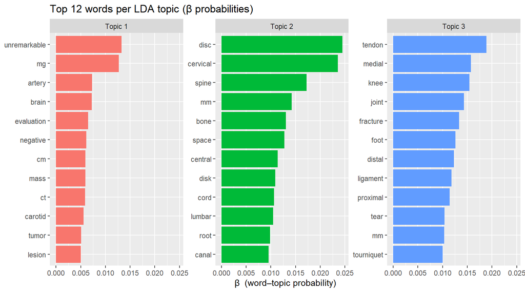

```r
lda_beta <- tidy(emr_lda, matrix = "beta")

lda_beta |>
  group_by(topic) |>
  slice_max(beta, n = 12, with_ties = FALSE) |>
  ggplot(aes(beta,
             reorder_within(term, beta, topic),
             fill = factor(topic))) +
  geom_col(show.legend = FALSE) +
  facet_wrap(~topic, scales = "free_y",
             labeller = labeller(topic = function(x) paste("Topic", x))) +
  scale_y_reordered() +
  labs(title = "Top 12 words per LDA topic (β probabilities)",
       x = "β  (word–topic probability)", y = NULL)
```

**Q11 (2 marks):** Based on the top words in the β plot, give each topic a brief descriptive clinical label (e.g., “imaging”, “musculoskeletal”, “neurological”). Which topic do you think corresponds most closely to which specialty, and why? Does the vocabulary in each topic match your expectations from the TF-IDF results in Section 6?

[output not shown]

### Document–topic distributions (γ) by specialty

The γ matrix tells us how much each document (i.e., transcript in this case) draws from each topic. We join it with specialty labels to see whether LDA-discovered topics align with the known clinical categories:

```r
lda_gamma <- tidy(emr_lda, matrix = "gamma")

lda_gamma_specialty <- lda_gamma |>
  left_join(
    filtered_data |>
      mutate(document = as.character(note_id)) |>
      select(document, medical_specialty),
    by = "document"
  )
```

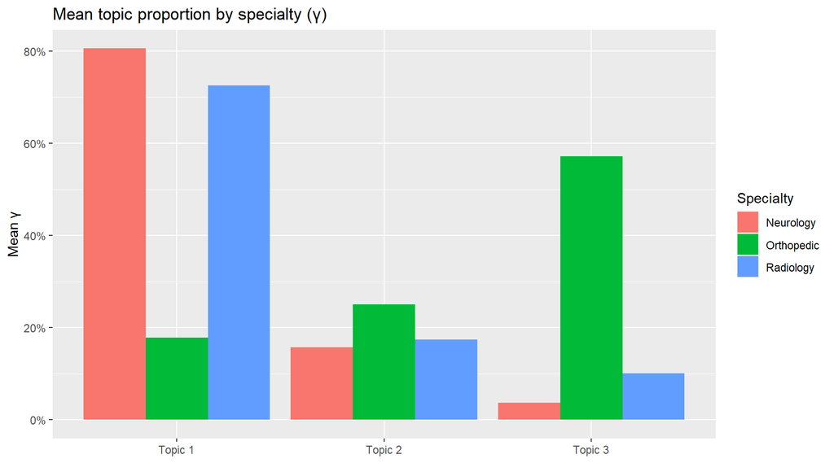

```r
lda_gamma_specialty |>
  group_by(medical_specialty, topic) |>
  summarise(mean_gamma = mean(gamma), .groups = "drop") |>
  mutate(topic = factor(topic, labels = paste("Topic", seq_len(k_topics)))) |>
  ggplot(aes(topic, mean_gamma, fill = medical_specialty)) +
  geom_col(position = "dodge") +
  scale_y_continuous(labels = percent_format(accuracy = 1)) +
  labs(title = "Mean topic proportion by specialty (γ)",
       x = NULL, y = "Mean γ", fill = "Specialty")
```

**Q12 (3 marks):**

1. Based on the γ plot, which specialty has the clearest dominant topic (i.e., one topic has a noticeably higher mean γ than the others for that specialty)? Does this align with the clinical label you assigned to that topic in Q11?

```
Q12 (a) Answer:
Neurology has the clearest dominant topic because Topic 1 has the highest mean γ value (0.806), which is substantially larger than the dominant topic proportions observed for the other specialties. This indicates that Neurology notes are more strongly concentrated around a single topic than Orthopedic or Radiology notes.
This partially aligns with the clinical labels assigned in Q11. Topic 3 was clearly associated with Orthopedic vocabulary, while Topic 1 appears to capture many terms related to Neurology and Radiology. The strong dominance of Topic 1 for Neurology suggests that neurological notes share a particularly consistent vocabulary.
```

2. Uncomment and complete the code below to compute, for each specialty, the single topic with the highest mean γ. Replace each `___` with the correct column name or expression.

```r
lda_gamma_specialty |>
  group_by(medical_specialty, topic) |>
  summarise(mean_gamma = mean(gamma), .groups = "drop") |>
  group_by(medical_specialty) |>
  slice_max(mean_gamma, n = 1)
```

```
## # A tibble: 3 × 3
## # Groups:   medical_specialty [3]
##   medical_specialty topic mean_gamma
##   <chr>             <int>      <dbl>
## 1 Neurology             1      0.806
## 2 Orthopedic            3      0.571
## 3 Radiology             1      0.725
```

Q12 (b) Answer: The dominant topic for Neurology is Topic 1 (mean γ = 0.806), for Orthopedic is Topic 3 (mean γ = 0.571), and for Radiology is Topic 1 (mean γ = 0.725). Neurology shows the strongest topic dominance overall, followed by Radiology and then Orthopedic.

3. Sun et al. (2024) ran LDA on social work notes *without knowing in advance* what topics would emerge. How does their situation differ from this exercise, where we set `k = 3` to match three known specialties? What does this suggest about how to choose the number of topics *k* in a real exploratory analysis?

Q12(c) Answer:

## In this exercise, we knew beforehand that the dataset contained three specialties, so we set k = 3 to match the expected number of groups. In contrast, Sun et al. (2024) applied LDA in an exploratory setting where the underlying topics were unknown. This suggests that in real-world analyses, the number of topics should be selected through experimentation, model evaluation, and interpretability rather than being predetermined.

## LLMs for Clinical Text Analysis

Finally, let’s address the LLM in the room. Chung et al. (2024) showed that GPT-4 Turbo, with no task-specific training, could classify perioperative outcomes from pre-operative notes using carefully designed prompts (zero-shot, few-shot, chain-of-thought).

Let’s experiment similarly to classify a single note and then compare its reasoning with the LDA topic model’s assignment. You can use whichever LLM you are comfortable using (Dalhousie students have access to Microsoft Copilot via Office 365 (copilot.microsoft.com) with some degree of data protection/agreements).

### Sample note

```r
# Sample from notes that appear in the topic model
set.seed(42)
dtm_note_ids <- as.integer(rownames(emr_dtm))

q10_note <- filtered_data |>
  filter(note_id %in% dtm_note_ids) |>
  slice_sample(n = 1)

cat("=== True specialty:", q10_note$medical_specialty, "===\n\n")
```

```
## === True specialty: Orthopedic ===
```

```r
cat("Description:", q10_note$description, "\n\n")
```

```
## Description: Bunionectomy, right foot with Biopro hemi implant, right first metatarsophalangeal joint.  Arthrodesis, right second, third, and fourth toes with external rod fixation.  Hammertoe repair, right fifth toe.  Extensor tenotomy and capsulotomy, right fourth metatarsophalangeal joint.  Mo…
##
```

```r
cat("--- Transcription (first 1200 characters) ---\n")
```

```
## --- Transcription (first 1200 characters) ---
```

```r
cat(str_trunc(q10_note$transcription, 1200))
```

```
## PREOPERATIVE DIAGNOSES:,1.  Hallux abductovalgus, right foot.,2.  Hammer toe, right foot, second, third, fourth and fifth toes.,3.  Tailor's bunionette, right foot.,4.  Degenerative joint disease, right first metatarsophalangeal joint.,5.  Rheumatoid arthritis.,6.  Contracted fourth right metatar…
```

LDA topic assignment for this note (γ values, highest first):

```r
lda_gamma_specialty |>
  filter(document == as.character(q10_note$note_id)) |>
  mutate(topic = paste("Topic", topic)) |>
  arrange(desc(gamma))
```

```
## # A tibble: 3 × 4
##   document topic      gamma medical_specialty
##   <chr>    <chr>      <dbl> <chr>
## 1 2299     Topic 3 1.000    Orthopedic
## 2 2299     Topic 2 0.000164 Orthopedic
## 3 2299     Topic 1 0.000164 Orthopedic
```

**Q13 (3 marks):** Copy the transcription above into Microsoft Copilot and use the following prompt:

> *“I will give you a medical transcription. Classify it as exactly one of: Orthopedic, Radiology, or Neurology. Think step by step and explain your reasoning before giving your final answer. Transcription: [paste text here]”*
1. What specialty did the LLM predict, and was it correct? Does it match the topic with the highest γ from the LDA model above?

Q13 (a) Answer: The LLM predicted Orthopedic, which is the correct specialty for this transcription. The note focuses on musculoskeletal conditions and surgical procedures involving the foot, including bunionectomy, hammertoe repair, arthrodesis, and joint disease. This prediction is consistent with the LDA model, which assigned the highest γ value to Topic 3 (γ = 0.9997). Topic 3 was previously identified as the Orthopedic/Musculoskeletal topic, so both methods arrived at the same conclusion.

2. What specific features of the text did the LLM cite to justify its classification?

Q13 (b) Answer: The LLM based its classification on several orthopedic features in the note, including references to bunionectomy, hammertoe repair, arthrodesis, metatarsophalangeal joints, foot deformities, and rheumatoid arthritis. These terms describe musculoskeletal anatomy and orthopedic surgical procedures, which strongly indicate the Orthopedic specialty.

3. Compare LLM’s explanation-based classification with LDA’s unsupervised topic assignment. Which approach would you prefer for classifying a large batch of new clinical notes, and why?

Q13 (c) Answer: The LLM provides an explanation for its prediction, making it easier to understand why a note was assigned to a particular specialty. In contrast, LDA is an unsupervised method that identifies patterns of word usage without directly producing a clinical rationale.

For classifying a large batch of new clinical notes, I would generally prefer an LLM because it can use contextual information and provide interpretable reasoning. However, LDA remains useful for exploratory analysis when categories are unknown or when discovering latent themes in large collections of documents.

## Tying back to the literature

**Q14 (1 mark):** Sun et al. (2024) applied LDA topic modelling to clinical social work notes to explore SDoH factors. Name two of the SDoH-related topics they identified and state the name of the metric they used to evaluate topic quality (hint: it measures the coherence of the top words within a topic).

Q14 Answer: Sun et al. (2024) identified several SDoH-related topics, including housing insecurity and financial/insurance concerns. They evaluated topic quality using the topic coherence metric, which measures how semantically related the top words within a topic are.

**Q15 (1 mark):** Chung et al. (2024) tested GPT-4 Turbo on both classification and numerical prediction tasks. Name one task where the LLM performed well (give the F1 score) and one where it failed to beat a simple baseline (give the MAE and the baseline value for comparison).

Q15 Answer:

Chung et al. (2024) found that GPT-4 Turbo performed well on ICU admission prediction, achieving an F1 score of 0.81. It also performed strongly on hospital mortality prediction with an F1 score of 0.86. However, the model failed to outperform a simple baseline on some numerical prediction tasks. For example, in PACU phase 1 duration prediction, GPT-4 Turbo achieved a mean absolute error (MAE) of 49 minutes, compared with the dummy-regressor baseline MAE of 36 minutes. This indicates that the LLM was less accurate than the simple baseline for this task.

*Dataset: MTSamples via `clinspacy` (mtsamples.com) with material drawn from Silge & Robinson,* Text Mining with R *(tidytextmining.com)*